# Trabajo Práctico Grupal - Seminario Mercado de Trabajo y Empleo

Melisa Laurora y Francisco Fernández

2024-07-12

# Análisis Brasil

El siguiente trabajo práctico es condición obligatoria para la promoción de la materia **Mercado de trabajo y empleo de la Maestría en Generación y Analisis de Información Estadística de la UNTREF**. El mismo es de resolución grupal.

#### Fecha de entrega:

Viernes 12 de julio. La entrega será un informe en Rmarkdown alojado en un repositorio de Github que pueda correrse desde cualquier computadora, con la base datos correspondiente en el directorio de trabajo.

## 1) Abrir y explorar las distintas bases de datos. Describir brevemente la metodología con que la encuesta es elaborada y explicar (en un tabulado) las variables que serán utilizadas en el TP.

### PNAD Continua - Encuesta Nacional Continua por Muestra de Hogares

Tiene como objetivo principal seguir las fluctuaciones trimestrales y la evolución en la inserción de la población en el mercado laboral y características como edad, sexo y nivel de educación, además de permitir el estudio del desarrollo socioeconómico del país a través de la producción de datos anuales sobre otras formas de trabajo. Es una encuesta integrada de viviendas; con muestreo probabilístico; frecuencia de divulgación trimestral/ anual; población objetivo compuesta por todas las personas que viven en hogares privados permanentes en el área cubierta por la investigación (Grandes Regiones, Unidades de Federación, 20 Regiones Metropolitanas que contienen Municipios Capitales, Municipios de las Capitales y Región de Desarrollo Integrado de la Gran Teresina).

Fuente: https://www.ibge.gov.br/estatisticas/sociais/trabalho/17270-pnad-continua.html?=&t=o-que-e

```r
var<-read.csv("Variables.csv", sep=";",na.strings=c("NA","NULL"),encoding="UTF-8")

var%>%
  kable() %>%
  kable_styling(bootstrap_options = c("striped", "hover", "condensed", "responsive"))
```

| Indicadores | Operacionalización | Variables.utilizadas |
| --- | --- | --- |
| Población económicamente activa: | la integran las personas que tienen una ocupación o que, sin tenerla, la están buscando activamente. Está compuesta por la población ocupada más la población desocupada. | VD4002 |
| Población ocupada: | conjunto de personas que tienen por lo menos una ocupación, es decir que en la semana de referencia han trabajado como mínimo una hora (en una actividad económica). El criterio de una hora trabajada, … | VD4002 |
| Población desocupada: | personas que, no teniendo ocupación, están buscando activamente trabajo y están disponibles para trabajar. Corresponde a la desocupación abierta. Este concepto no incluye otras formas de precariedad l… | VD4002 |
| Población subocupada | Aquellos que trabajan pero les gustaría trabajar más horas. | V1028,VD4004, VD4004A |
| Tasa de empleo: | porcentaje entre la población ocupada y la población total de referencia. | V1028,VD4002 |
| Tasa de desocupación: | porcentaje entre la población desocupada y la población económicamente activa. | V1029,VD4002 |
| Tasa de subocupación: | proporción de la PEA que se encuentra subocupada. | V1028,VD4002,VD4004, VD4004A |

## 2) Estimar y presentar las tasas básicas del mercado de trabajo. Analizar brevemente los resultados encontrados.

```r
if (!require('scales')) install.packages('scales'); library('scales')

Tasas_basicas <- base %>%
  summarise(Poblacion         = sum(V1028),
            Ocupados          = sum(V1028[VD4002 == "Pessoas ocupadas"],na.rm=TRUE),
            Desocupados       = sum(V1028[VD4002 == "Pessoas desocupadas"],na.rm=TRUE),
            PEA               = Ocupados + Desocupados,
            Subocupados       =  sum(V1028[(VD4004 =="Pessoas subocupadas"|VD4004A=="Pessoas subocupadas")],na.rm=TRUE),
            'Tasa Actividad'                  = percent(PEA/Poblacion, accuracy = 0.1),
            'Tasa Empleo'                     = percent(Ocupados/Poblacion, accuracy = 0.1),
            'Tasa Desocupacion'               = percent(Desocupados/PEA, accuracy = 0.1),
            'Tasa Subocupación'               = percent(Subocupados/PEA, accuracy = 0.1))

#Visualizamos los indicadores básicos de España y Reino Unido
kable(Tasas_basicas, format = "html", table.attr = "class='table table-striped'", caption = "Tasas Básicas del Mercado de Trabajo de Brasil - 2019, 3er trimestre. Fuente: PNAD continua") %>%
  kable_styling(full_width = F, position = "center")
```

Tasas Básicas del Mercado de Trabajo de Brasil - 2019, 3er trimestre. Fuente: PNAD continua

| Poblacion | Ocupados | Desocupados | PEA | Subocupados | Tasa Actividad | Tasa Empleo | Tasa Desocupacion | Tasa Subocupación |
| --- | --- | --- | --- | --- | --- | --- | --- | --- |
| 209677912 | 93800646 | 12514772 | 106315418 | 7043809 | 50.7% | 44.7% | 11.8% | 6.6% |

Se observa que la tasa de actividad es de un 50,7%, la tasa de empleo 44,7% y la de desocupación 11,8%.

## 3) Realizar una operacionalización de los conceptos de Sector Formal y Sector Informal, de modo de clasificar a toda la población activa en alguno de estos dos sectores. Explicar qué variables se eligieron y por qué.

El concepto de sector formal e informal se remonta a la década del 60, abordando la informalidad en términos de “sector”, siendo sus ejes principales la superposición de la unidad doméstica y la unidad económica, la contraposición de la lógica de supervivencia y la lógica de acumulación, la escala de reproducción de la unidad económica, etc. (Pok, 2013) Para el presente trabajo se considerará:

- Trabajadores familiares: se encontrarán dentro del sector informal.
- Asalariados: quienes cuenten con aportes jubilatorios estarán dentro del mercado formal. Quienes no cuenten con esto se considerarán dentro del sector informal.
- Cuenta propistas: con trabajo calificado se encontrarán dentro del sector formal. Quienes no cuenten con calificaciones se encontrarán en el sector informal. En el caso de las trabajadoras domésticas, se las incluirá dentro de la categoría “cuentapropista”.
- Empleadores: según el tamaño del establecimiento. Hasta 5 trabajadores formarán parte del sector informal, más trabajadores serán formales.
- Militares o servidores estatutarios: sector formal

## 4) Realizar una operacionalización del concepto de precariedad laboral, clasificando a toda la población asalariada.

Se considerará trabajadores precarios a quienes sean empleados (del sector público o privado) y tengan un trabajo de tipo temporario. Además, se considerará a quienes sean trabajadores familiares auxiliares. También se considerará a quienes realizan el trabajo en el domicilio del empleador, patron o socio.

Se considerará trabajadores no precarios a quienes sean empleados (del sector público o privado) y tengan un trabajo de tipo permanente. Además, se considerará a quienes sean militares o servidores estatutarios.

## 5) Presentar de forma tabulada la incidencia de la informalidad y la precariedad en la población ocupada y/o asalariada.

```r
base<-base %>% mutate(Formalidad = case_when(
  VD4009 == "Empregado no setor privado com carteira de trabalho assinada"~ "Formal",###Formal
  VD4009 == "Empregado no setor público com carteira de trabalho assinada"~ "Formal",
  VD4009 == "Militar e servidor estatutário"~ "Formal",
  VD4009 == "Trabalhador doméstico com carteira de trabalho assinada"~ "Formal",
  VD4009 == "Conta-própria"&VD3004 =="Superior incompleto ou equivalente"~ "Formal",
  VD4009 == "Conta-própria"&VD3004 =="Superior completo"~ "Formal",
  VD4009 == "Empregador"&V4016 == "6 a 10 empregados"~ "Formal",
  VD4009 == "Empregador"&V4016 == "11 a 50 empregados"~ "Formal",
  VD4009 == "Empregador"&V4016 == "51 ou mais empregados"~ "Formal",
  VD4009 == "Empregado no setor privado sem carteira de trabalho assinada"~ "Informal",###Informal
  VD4009 == "Empregado no setor público sem carteira de trabalho assinada"~ "Informal",
  VD4009 == "Trabalhador doméstico sem carteira de trabalho assinada"~ "Informal",
  VD4009 == "Trabalhador familiar auxiliar"~ "Informal",
  VD4009 == "Conta-própria"&VD3004 =="Sem instrução e menos de 1 ano de estudo"~ "Informal",
  VD4009 == "Conta-própria"&VD3004 =="Fundamental incompleto ou equivalente" ~ "Informal",
  VD4009 == "Conta-própria"&VD3004 =="Fundamental completo ou equivalente" ~ "Informal",
  VD4009 == "Conta-própria"&VD3004 =="Médio incompleto ou equivalente" ~ "Informal",
  VD4009 == "Conta-própria"&VD3004 =="Médio completo ou equivalente"~ "Informal",
  VD4009 == "Empregador"&V4016 == "1 a 5 empregados"~ "Informal"))
Formalidad <- base %>%
  summarise(Ocupados          = sum(V1028[VD4002 == "Pessoas ocupadas"],na.rm=TRUE),
            Sector_formal= sum(V1028[Formalidad == "Formal"],na.rm=TRUE),
            Sector_informal= sum(V1028[Formalidad == "Informal"],na.rm=TRUE),
            'Tasa Formalidad'= percent(Sector_formal/Ocupados, accuracy = 0.1),
            'Tasa Informalidad'= percent(Sector_informal/Ocupados, accuracy = 0.1))

base<-base %>% mutate(Precariedad = case_when(((
  #Precarios
  VD4009 == "Empregado no setor privado com carteira de trabalho assinada"|
    VD4009 == "Empregado no setor privado com carteira de trabalho assinada"|
    VD4009 == "Empregado no setor público com carteira de trabalho assinada"|
    VD4009 == "Empregado no setor privado sem carteira de trabalho assinada"|
    VD4009 == "Empregado no setor público sem carteira de trabalho assinada")&
    (V4025=="Sim"|V4022=="Em domicílio de empregador, patrão, sócio ou freguês"))~"Precario",
   (VD4009 == "Trabalhador familiar auxiliar"|
    VD4009 == "Trabalhador doméstico com carteira de trabalho assinada"|
    VD4009 == "Trabalhador doméstico sem carteira de trabalho assinada")~"Precario",
  #No precarios
  ((VD4009 == "Empregado no setor privado com carteira de trabalho assinada"|                                                     VD4009 == "Empregado no setor público com carteira de trabalho assinada"|                                                     VD4009 == "Empregado no setor privado sem carteira de trabalho assinada"|                                                     VD4009 == "Empregado no setor público sem carteira de trabalho assinada")&(V4025=="Não"))~"No precario",
  VD4009 == "Militar e servidor estatutário"~"No precario"))
base<-base %>% mutate(Asalariado = case_when((
    VD4009 == "Empregado no setor privado com carteira de trabalho assinada"|
    VD4009 == "Empregado no setor público com carteira de trabalho assinada"|
    VD4009 == "Empregado no setor privado sem carteira de trabalho assinada"|
    VD4009 == "Empregado no setor público sem carteira de trabalho assinada"|
    VD4009 == "Trabalhador familiar auxiliar"|
    VD4009 == "Militar e servidor estatutário"|
    VD4009 == "Trabalhador doméstico com carteira de trabalho assinada"|
    VD4009 == "Trabalhador doméstico sem carteira de trabalho assinada")~"Asalariado"))

PrecariedadyFormalidad <- base %>%
  summarise(Asalariados          = sum(V1028[Asalariado == "Asalariado"],na.rm=TRUE),
            Sector_precario= sum(V1028[Precariedad == "Precario"],na.rm=TRUE),
            Sector_no_precario= sum(V1028[Precariedad == "No precario"],na.rm=TRUE),
            'Proporción de Precariedad'= percent(Sector_precario/Asalariados, accuracy = 0.1),
            'Proporción de No precariedad'= percent(Sector_no_precario/Asalariados, accuracy = 0.1),
            Ocupados          = sum(V1028[VD4002 == "Pessoas ocupadas"],na.rm=TRUE),
            Sector_formal= sum(V1028[Formalidad == "Formal"],na.rm=TRUE),
            Sector_informal= sum(V1028[Formalidad == "Informal"],na.rm=TRUE),
            'Proporción de Formalidad'= percent(Sector_formal/Ocupados, accuracy = 0.1),
            'Proporción de Informalidad'= percent(Sector_informal/Ocupados, accuracy = 0.1))


#Visualizamos los indicadores básicos de Brasil
kable(PrecariedadyFormalidad, format = "html", table.attr = "class='table table-striped'", caption = "Tasas de Precariedad e Informalidad del Mercado de Trabajo de Brasil - 2019, 3er trimestre. Fuente: PNAD continua") %>%  kable_styling(full_width = F, position = "center")
```

Tasas de Precariedad e Informalidad del Mercado de Trabajo de Brasil - 2019, 3er trimestre. Fuente: PNAD continua

| Asalariados | Sector_precario | Sector_no_precario | Proporción de Precariedad | Proporción de No precariedad | Ocupados | Sector_formal | Sector_informal | Proporción de Formalidad | Proporción de Informalidad |
| --- | --- | --- | --- | --- | --- | --- | --- | --- | --- |
| 64998833 | 14779199 | 50219634 | 22.7% | 77.3% | 93800646 | 49424907 | 44375740 | 52.7% | 47.3% |

## 6) Analizar la incidencia de la informalidad y la precariedad según sexo y edad.

### Formalidad por sexo

Se observa niveles similares de formalidad entre ambos sexos.

```r
if (!require('janitor')) install.packages('janitor'); library('janitor')
if (!require('viridis')) install.packages('viridis'); library('viridis')
FormalidadxSexo <- base %>%filter(Formalidad=="Formal"|Formalidad=="Informal")%>% group_by(Formalidad,V2007) %>% summarise(n=n())%>% spread(V2007,n) %>%
      adorn_totals(c("row", "col"))  %>%
  adorn_percentages("row") %>%
  adorn_pct_formatting(digits = 1) %>%
  adorn_ns()


kable(FormalidadxSexo, format = "html", table.attr = "class='table table-striped'", caption = "Sector formal y Sector Informal del Mercado de Trabajo según sexo. Población Económicamente Activa. Brasil - 2019, 3er trimestre. Fuente: PNAD continua") %>%
  kable_styling(full_width = F, position = "center")
```

Sector formal y Sector Informal del Mercado de Trabajo según sexo. Población Económicamente Activa. Brasil - 2019, 3er trimestre. Fuente: PNAD continua

| Formalidad | Homem | Mulher | Total |
| --- | --- | --- | --- |
| Formal | 55.2% (60,986) | 44.8% (49,449) | 100.0% (110,435) |
| Informal | 60.1% (74,060) | 39.9% (49,166) | 100.0% (123,226) |
| Total | 57.8% (135,046) | 42.2% (98,615) | 100.0% (233,661) |

### Formalidad Por edad

```r
#### Genero rangos etarios
base$V2009<-as.numeric(base$V2009)
base <- base  %>% mutate( GRUPO_EDAD = cut(V2009,
                                         breaks = c(15, 30, 45, 60, Inf),
                                         labels = c("15-30", "30-45", "45-60", "60 o más"),
                                         include.lowest = TRUE)) %>% filter(!is.na(GRUPO_EDAD))

FormalidadxEdad <- base %>% filter(V2009<100)%>%filter(Formalidad=="Formal"|Formalidad=="Informal")%>% group_by(Formalidad,GRUPO_EDAD) %>% summarise(n=n())%>% spread(Formalidad,n) %>%
    adorn_totals(c("row", "col"))  %>%
  adorn_percentages("row") %>%
  adorn_pct_formatting(digits = 1) %>%
  adorn_ns()

kable(FormalidadxEdad, format = "html", table.attr = "class='table table-striped'", caption = "Formalidad del Mercado de Trabajo de Brasil según edad. Población Económicamente Activa. 2019, 3er trimestre. Fuente: PNAD continua") %>%
  kable_styling(full_width = F, position = "center")
```

Formalidad del Mercado de Trabajo de Brasil según edad. Población Económicamente Activa. 2019, 3er trimestre. Fuente: PNAD continua

| GRUPO_EDAD | Formal | Informal | Total |
| --- | --- | --- | --- |
| 15-30 | 48.4% (31,068) | 51.6% (33,185) | 100.0% (64,253) |
| 30-45 | 52.3% (46,259) | 47.7% (42,141) | 100.0% (88,400) |
| 45-60 | 44.3% (28,038) | 55.7% (35,280) | 100.0% (63,318) |
| 60 o más | 29.3% (5,053) | 70.7% (12,203) | 100.0% (17,256) |
| Total | 47.3% (110,418) | 52.7% (122,809) | 100.0% (233,227) |

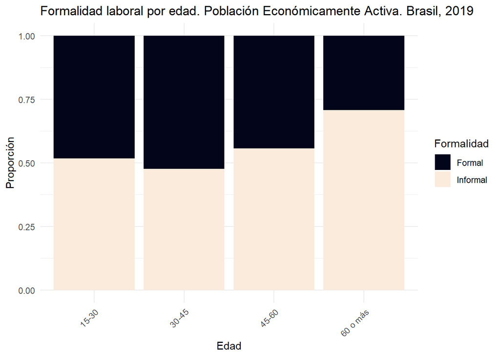

```r
FormalidadxEdad <- base %>% filter(V2009<100)%>%filter(Formalidad=="Formal"|Formalidad=="Informal")%>% group_by(Formalidad,GRUPO_EDAD) %>% summarise(n=n())
ggplot(FormalidadxEdad, aes(fill=Formalidad, y=n, x=GRUPO_EDAD)) +
    geom_bar(position="fill", stat="identity") +
    scale_fill_viridis(discrete = T, option = "F")+
  labs(title = "Formalidad laboral por edad. Población Económicamente Activa. Brasil, 2019",
       x="Edad",y="Proporción")+ theme_minimal() +theme(axis.text.x = element_text(angle = 45, hjust = 1))
```

### Precariedad por sexo

Se observa mayor proporción de precariedad entre el sexo femenino, respecto al masculino.

```r
PrecariedadxSexo <- base %>%filter(Precariedad=="Precario"|Precariedad=="No precario")%>% group_by(Precariedad,V2007) %>% summarise(n=n())%>% spread(V2007,n) %>%
      adorn_totals(c("row", "col"))  %>%
  adorn_percentages("row") %>%
  adorn_pct_formatting(digits = 1) %>%
  adorn_ns()

kable(PrecariedadxSexo, format = "html", table.attr = "class='table table-striped'", caption = "Tasas de Precariedad e Informalidad del Mercado de Trabajo de Brasil según sexo - 2019, 3er trimestre. Fuente: PNAD continua") %>%
  kable_styling(full_width = F, position = "center")
```

Tasas de Precariedad e Informalidad del Mercado de Trabajo de Brasil según sexo - 2019, 3er trimestre. Fuente: PNAD continua

| Precariedad | Homem | Mulher | Total |
| --- | --- | --- | --- |
| No precario | 59.0% (67,663) | 41.0% (47,116) | 100.0% (114,779) |
| Precario | 36.9% (15,524) | 63.1% (26,538) | 100.0% (42,062) |
| Total | 53.0% (83,187) | 47.0% (73,654) | 100.0% (156,841) |

### Precariedad por edad

```r
PrecariedadxEdad <- base %>% filter(V2009<100)%>%filter(Precariedad=="Precario"|Precariedad=="No precario")%>% group_by(Precariedad,GRUPO_EDAD) %>% summarise(n=n())%>% spread(Precariedad,n) %>%
    adorn_totals(c("row", "col"))  %>%
  adorn_percentages("row") %>%
  adorn_pct_formatting(digits = 1) %>%
  adorn_ns()

kable(PrecariedadxEdad, format = "html", table.attr = "class='table table-striped'", caption = "Precariedad e Informalidad del Mercado de Trabajo de Brasil según edad  - 2019, 3er trimestre. Fuente: PNAD continua") %>%
  kable_styling(full_width = F, position = "center")
```

Precariedad e Informalidad del Mercado de Trabajo de Brasil según edad - 2019, 3er trimestre. Fuente: PNAD continua

| GRUPO_EDAD | No precario | Precario | Total |
| --- | --- | --- | --- |
| 15-30 | 71.6% (36,647) | 28.4% (14,525) | 100.0% (51,172) |
| 30-45 | 75.7% (46,281) | 24.3% (14,850) | 100.0% (61,131) |
| 45-60 | 72.3% (27,132) | 27.7% (10,398) | 100.0% (37,530) |
| 60 o más | 67.3% (4,719) | 32.7% (2,288) | 100.0% (7,007) |
| Total | 73.2% (114,779) | 26.8% (42,061) | 100.0% (156,840) |

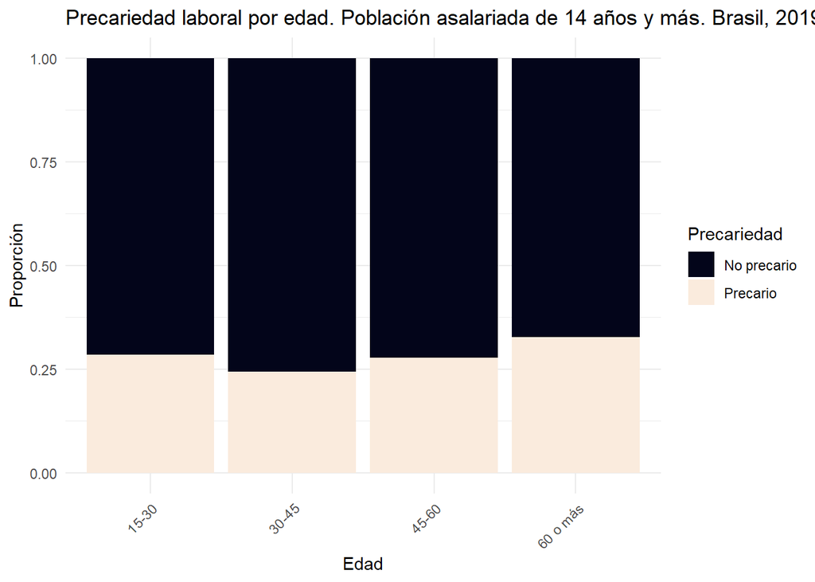

```r
PrecariedadxEdad <- base %>% filter(V2009<100)%>%filter(Precariedad=="Precario"|Precariedad=="No precario")%>% group_by(Precariedad,GRUPO_EDAD) %>% summarise(n=n())
ggplot(PrecariedadxEdad, aes(fill=Precariedad, y=n, x=GRUPO_EDAD)) +
    geom_bar(position="fill", stat="identity") +
    scale_fill_viridis(discrete = T, option = "F")+
  labs(title = "Precariedad laboral por edad. Población asalariada de 14 años y más. Brasil, 2019",
       x="Edad",y="Proporción")+ theme_minimal() +theme(axis.text.x = element_text(angle = 45, hjust = 1))
```

# Análisis España y Reino Unido

## 1) Abrir y explorar las distintas bases de datos. Describir brevemente la metodología con que la encuesta es elaborada y explicar las variables que serán utilizadas en el TP.

La Encuesta de Fuerza de Trabajo de la Unión Europea (EU-LFS de ahora en más) es la encuesta de hogares e individuos más extensa de la Unión Europea. Su objetivo estadístico principal es clasificar a las personas en tres categorías mutuamente excluyentes: empleados,desempleados y personas por fuera de la fuerza de trabajo. Esta encuesta se realiza de forma trimestral en todos los países de la Unión Europea en un formato estandarizado para todos los países, facilitando así la comparación entre ellos. La población a la cual se le puede realizar la encuesta es de 15 años o más.

Las variables a utilizar, tanto para el caso de España como de Reino Unido, serán las siguentes:

```r
Variables <- c("WSTATOR", "MAINSTAT", "COEFF", "STAPRO","SIZEFIRM","TEMP","HWOVERPU","SEEKWORK","AVAILBLE","SIGNISAL","SEX","AGE","ISCO3D")
Descripcion <- c("Estado laboral durante la semana de referencia",
                  "Estado laboral general",
                  "Factor ponderador de la poblacion",
                  "Estatus Profesional",
                  "Tamaño de la empresa",
                  "Trabajo Temporal o Permanente",
                  "Cantidad de horas extras no pagas durante la semana de referencia",
                  "En búsqueda laboral",
                  "Disponibilidad para empezar a trabajar en las próximas dos semanas",
                  "Percibe regularmente su salario, aunque no asistió al trabajo en la semana de referencia",
                  "Sexo",
                  "Edad",
                  "Tipo de Ocupación")


variable_table <- data.frame(Variable = Variables, Description = Descripcion)

variable_table %>%
  kable() %>%
  kable_styling(bootstrap_options = c("striped", "hover", "condensed", "responsive"))
```

| Variable | Description |
| --- | --- |
| WSTATOR | Estado laboral durante la semana de referencia |
| MAINSTAT | Estado laboral general |
| COEFF | Factor ponderador de la poblacion |
| STAPRO | Estatus Profesional |
| SIZEFIRM | Tamaño de la empresa |
| TEMP | Trabajo Temporal o Permanente |
| HWOVERPU | Cantidad de horas extras no pagas durante la semana de referencia |
| SEEKWORK | En búsqueda laboral |
| AVAILBLE | Disponibilidad para empezar a trabajar en las próximas dos semanas |
| SIGNISAL | Percibe regularmente su salario, aunque no asistió al trabajo en la semana de referencia |
| SEX | Sexo |
| AGE | Edad |
| ISCO3D | Tipo de Ocupación |

## 2) Estimar y presentar las tasas básicas del mercado de trabajo. Analizar brevemente los resultados encontrados.

```r
## Cargamos las bases de datos
bbdd_uk=read.csv("reino_unido.csv")

bbdd_espana=read.csv("espana.csv")

## Calculamos los indicadores básicos laborales para España y Reino Unido

Cuadro_2_ESPAÑA <- bbdd_espana %>%
  summarise(País="España",
            Poblacion             = sum(COEFF*1000, na.rm = TRUE),
            Ocupados              = sum((WSTATOR %in% c(1,2))*(COEFF*1000),na.rm=TRUE),
            #Ocupados_OIT         = sum((ILOSTAT %in% c(1))*(COEFF*1000),na.rm=TRUE),
            Desocupados           = sum((SEEKWORK %in% c(1,2,4))*(COEFF*1000),na.rm=TRUE),
            #Desocupados_OIT      = sum((ILOSTAT %in% c(2))*(COEFF*1000),na.rm=TRUE),
            #Inactivos   = sum((SEEKWORK %in% c(3)|AVAILBLE %in% c(2))*(COEFF*1000),na.rm=TRUE),
            #Inactivos_OIT        = sum((ILOSTAT %in% c(3))*(COEFF*1000),na.rm=TRUE),
            #Menores              = sum((WSTATOR %in% c(9))*(COEFF*1000),na.rm=TRUE),
            PEA                   = Ocupados + Desocupados,
            'Tasa Actividad'      = percent(PEA/Poblacion, accuracy = 0.1),
            'Tasa Empleo'         = percent(Ocupados/Poblacion, accuracy = 0.1),
            'Tasa Desocupacion'   = percent(Desocupados/PEA, accuracy = 0.1)
            )

Cuadro_2_UK <- bbdd_uk %>%
  summarise(País="Reino Unido",
            Poblacion             = sum(COEFF*1000, na.rm = TRUE),
            Ocupados              = sum((WSTATOR %in% c(1,2))*(COEFF*1000),na.rm=TRUE),
            #Ocupados_OIT         = sum((ILOSTAT %in% c(1))*(COEFF*1000),na.rm=TRUE),
            Desocupados           = sum((SEEKWORK %in% c(1,2,4))*(COEFF*1000),na.rm=TRUE),
            #Desocupados_OIT      = sum((ILOSTAT %in% c(2))*(COEFF*1000),na.rm=TRUE),
            #Inactivos   = sum((SEEKWORK %in% c(3)|AVAILBLE %in% c(2))*(COEFF*1000),na.rm=TRUE),
            #Inactivos_OIT        = sum((ILOSTAT %in% c(3))*(COEFF*1000),na.rm=TRUE),
            #Menores              = sum((WSTATOR %in% c(9))*(COEFF*1000),na.rm=TRUE),
            PEA                   = Ocupados + Desocupados,
            'Tasa Actividad'      = percent(PEA/Poblacion, accuracy = 0.1),
            'Tasa Empleo'         = percent(Ocupados/Poblacion, accuracy = 0.1),
            'Tasa Desocupacion'   = percent(Desocupados/PEA, accuracy = 0.1)
            )
```

```r
# Agregamos separadores de miles
Cuadro_2_ESPAÑA <- Cuadro_2_ESPAÑA %>%
  mutate(across(c(Poblacion, Ocupados, Desocupados, PEA), ~ format(., big.mark = ".", decimal.mark = ",")))

Cuadro_2_UK <- Cuadro_2_UK %>%
  mutate(across(c(Poblacion, Ocupados, Desocupados, PEA), ~ format(., big.mark = ".", decimal.mark = ",")))

# Unificar los datasets
Cuadro_Indicadores_Basicos_Union <- bind_rows(Cuadro_2_ESPAÑA, Cuadro_2_UK)

#Visualizamos los indicadores básicos de España y Reino Unido
kable(Cuadro_Indicadores_Basicos_Union, format = "html", table.attr = "class='table table-striped'", caption = "Tasas Básicas del Mercado de Trabajo de España y Reino Unido - 2018. Fuente: EU LFS 2018-Q1") %>%
  kable_styling(full_width = F, position = "center")
```

Tasas Básicas del Mercado de Trabajo de España y Reino Unido - 2018. Fuente: EU LFS 2018-Q1

| País | Poblacion | Ocupados | Desocupados | PEA | Tasa Actividad | Tasa Empleo | Tasa Desocupacion |
| --- | --- | --- | --- | --- | --- | --- | --- |
| España | 46.296.318 | 19.327.701 | 3.701.006 | 23.028.707 | 49.7% | 41.7% | 16.1% |
| Reino Unido | 65.624.754 | 32.443.029 | 1.706.992 | 34.150.022 | 52.0% | 49.4% | 5.0% |

Podemos observar que España tiene una tasa de actividad bastante similar a Reino Unido, mientras que encontramos diferencias significativas tanto en la tasa de Desocupación, como en la tasa de Empleo. Pongamos por tanto el foco en la tasa de Desocupación: España tiene 16,1% de desocupación en el período analizado, mientras que Reino Unido tiene 3 veces menos, siendo la tasa de 5%. Asimismo, al hacer una comparación de la tasa de Desocupación de España con Brasil, vemos que la de España también resulta ser ampliamente más alta. Posiblemente más adelante en el trabajo podamos observar si estos niveles de desocupación que observamos en España se explica por algún factor relacionado con la edad o el sexo de las personas.

## 3) Realizar una operacionalización de los conceptos de Sector Formal y Sector Informal, de modo de clasificar a toda la población activa en alguno de estos dos sectores. Explicar qué variables se eligieron y por qué.

Para la operacionalización de los conceptos de Sector Formal e Informal se utilizaron múltiples variables de manera conjunta. Estas variables ya fueron detalladas en el punto 1) de este trabajo. Ahora bien, varias de esas variables se utilizaron en simultáneo para construir distintos conceptos o elementos que, a nuestro entender, dan cuenta del sector en la que se enmarca un trabajador/a. En primer lugar, utilizamos la variable ISCO3D que refiere a una clasificación estandarizada del tipo de Ocupación desarrollada por la Organización Internacional del Trabajo. Para que esta variable resulte más operacionalizable se tomó el primer dígito de la misma (salvo caso que sea 999, que indica casos nulos) puesto que hace referencia al tipo de empleo y su nivel de calificación. La nueva variable toma el nombre de nuevo_ISCO3D en ambos datasets. Si la variable toma un valor entre 1 y 3 consideramos que se trata de un puesto de calificación intermedia y alta (Gerentes, Profesionales, Técnicos). Si toma los valores de 4,5,6,7 y 8 hace referencia a una calificación intermedia-baja y si toma el valor de 9 la calificación es baja.

En segundo lugar, se utiliza la variable de SIZEFIRM, que remite al tamaño de la empresa. Si la misma toma el valor de 10, se tiene 10 o menos empleados, mientras que si toma el valor de 99 refiere a que es una empresa sin empleados (es decir, se trata de un empleado a cuenta propia).

En todos los casos, se utilizó el factor de expansión COEFF, y la construcción de estos indicadores es tanto para la base de datos de España como para la de Reino Unido. De la misma manera, se utilizó como denominador a la población ocupada, identificada por la variable WSTATOR igual a 1 o 2.

Nuestro marco conceptual para la elección de las variables de tamaño de establecimiento y calificación para la determinación del sector formal e informal parten de los aportes de Pok:

“En el marco de este abordaje general, una variable de aproximación habitualmente utilizada –y adoptada en la EPH de Argentina- ha sido el tamaño de los establecimientos, considerado en términos de la cantidad de personal ocupado. Una de las aproximaciones consistió, entonces, en considerar como integrantes del Sector Informal, a los asalariados, patrones, cuenta propia y trabajadores sin salario del mismo estrato en términos de tamaño –pequeño- de las unidades económicas en las que están insertos. Su inclusión requirió sin embargo, de restricciones, entre cuales la más potente pareció ser la de la calificación.” (Pok, 2013, p:11-12)

## 4) Realizar una operacionalización del concepto de precariedad laboral, clasificando a toda la población asalariada.

Para el concepto de precarización laboral, utilizamos en primer lugar la variable HWOVERPU, que captura la cantidad de horas extras trabajadas que no fueron pagadas en la semana de referecia por el empleador. En ese sentido, si ya existía una hora extra no paga, lo contabilizamos como precariedad laboral. A su vez, incorporamos otra variable de suma importancia, TEMP, que remite a los contratos de tipo temporario (TEMP=2). Por último, nos parece importante utilizar la variable SIGNISAL, que refiere a la percepción o no del salario completo cuando el trabajador no asistió al trabajo en la semana de referencia.Como nuestro denominador vamos a utilizar la variable STAPRO para identificar exclusivamente a los empleados y a los trabajadores familiares (código 3 y 4 respectivamente), dejando por fuera a los cuentapropistas en este caso.

Por lo tanto, para identificar a un trabajador en situación de precariedad laboral, se debe cumplir una de tres condiciones: 1) No haber recibido el pago correspondiente a horas extras trabajadas durante la semana de referencia, 2) Tener un contrato laboral de tipo temporal o 3) No percepción del salario completo ante ausencia laboral.

Nuevamente, el marco conceptual para determinar las variables que nos sirven para determinar un trabajo como precario o no, parte de los aportes de Pok:

“Es de señalar que ya en la formulación inicial de la EPH se incluyó la medición de la falta de percepción de los distintos componentes de la cobertura propia del asalariado (descuento jubilatorio, obra social, aguinaldo, vacaciones, indemnización por despido, etc.). Estos rasgos se entendían como indicadores de pertenencia al sector formal de la economía, puesto que, para la época, la falta de cobertura sólo podía indicar la inserción en el sector informal. Esto, desde luego, con el advenimiento de la precariedad laboral, pasó a ser un indicador de esta última condición, con independencia del sector de ocurrencia.” (Pok, 2013, p:12)

Aunque muchas de estas variables mencionadas por Pok no se encuentran en los datos que recoge la encuesta EU-LFS, si pudimos establecer algunos indicadores de los países europeos que, teniendo en cuenta la realidad laboral y normativa, pueden dar cuenta de precarización laboral, como son las ya mencionadas variables de trabajo temporario, no pago de horas extra y recibo parcial del sueldo ante ausencia.

## 5) Presentar de forma tabulada la incidencia de la informalidad y la precariedad en la población ocupada y/o asalariada.

### Informalidad en España y Reino Unido

```r
# Primero, genero una nueva columna en nuestros datasets que tome solo el primer dígito de ISCO3D, que refiere al Tipo de Ocupación de acuerdo a la clasificación de la Organización Internacional del Trabajo. Con este dato, ya podemos empezar a determinar el nivel de calificación de la actividad.

bbdd_espana <- bbdd_espana %>%
  mutate(nuevo_ISCO3D = ifelse(ISCO3D == 999, 999, as.numeric(substr(ISCO3D, 1, 1))))

bbdd_uk <- bbdd_uk %>%
  mutate(nuevo_ISCO3D = ifelse(ISCO3D == 999, 999, as.numeric(substr(ISCO3D, 1, 1))))


## Calculamos la formalidad e informalidad en España

Cuadro_Formalidad_ESPAÑA <- bbdd_espana %>%
  summarise(
    Ocupados = sum((WSTATOR %in% c(1,2)) * (COEFF * 1000), na.rm = TRUE),
    Calificacion_Baja = sum((WSTATOR %in% c(1,2)) * (nuevo_ISCO3D %in% c(4,5,6,7,8,9,999)) * (COEFF * 1000), na.rm = TRUE),
    Empresas_Pequeñas_O_Sin_Empleados = sum((WSTATOR %in% c(1,2)) * (SIZEFIRM %in% c(10,99)) * (COEFF * 1000), na.rm = TRUE),
    Calificacion_Baja_Y_Empre_Peq = sum((WSTATOR %in% c(1,2)) * ((nuevo_ISCO3D %in% c(4,5,6,7,8,9,999)) & (SIZEFIRM %in% c(10,99))) * (COEFF * 1000), na.rm = TRUE),
    Informales = Calificacion_Baja_Y_Empre_Peq,
    Formales = Ocupados - Informales,
    'Porcentaje de Informalidad' = percent(Informales / Ocupados, accuracy = 0.1),
    'Porcentaje de Formalidad' = percent(Formales / Ocupados, accuracy = 0.1),
    País = "España"
  )


## Calculamos la formalidad e informalidad en Reino Unido

Cuadro_Formalidad_Reino_Unido <- bbdd_uk %>%
  summarise(
    Ocupados = sum((WSTATOR %in% c(1,2)) * (COEFF * 1000), na.rm = TRUE),
    Calificacion_Baja = sum((WSTATOR %in% c(1,2)) * (nuevo_ISCO3D %in% c(4,5,6,7,8,9,999)) * (COEFF * 1000), na.rm = TRUE),
    Empresas_Pequeñas_o_Sin_Empleados = sum((WSTATOR %in% c(1,2)) * (SIZEFIRM %in% c(10,99)) * (COEFF * 1000), na.rm = TRUE),
    Calificacion_Baja_Y_Empre_Peq = sum((WSTATOR %in% c(1,2)) * ((nuevo_ISCO3D %in% c(4,5,6,7,8,9,999)) & (SIZEFIRM %in% c(10,99))) * (COEFF * 1000), na.rm = TRUE),
    Informales = Calificacion_Baja_Y_Empre_Peq,
    Formales = Ocupados - Informales,
    'Porcentaje de Informalidad' = percent(Informales / Ocupados, accuracy = 0.1),
    'Porcentaje de Formalidad' = percent(Formales / Ocupados, accuracy = 0.1),
    País = "Reino Unido"
  )
```

```r
# Agregamos separadores de miles
Cuadro_Formalidad_ESPAÑA <- Cuadro_Formalidad_ESPAÑA %>%
  select(País,Ocupados,Formales,Informales,'Porcentaje de Formalidad','Porcentaje de Informalidad') %>%
  mutate(across(c(Ocupados,Formales,Informales), ~ format(., big.mark = ".", decimal.mark = ",")))

Cuadro_Formalidad_Reino_Unido <- Cuadro_Formalidad_Reino_Unido %>%
  select(País,Ocupados,Formales,Informales,'Porcentaje de Formalidad','Porcentaje de Informalidad') %>%
  mutate(across(c(Ocupados,Formales,Informales), ~ format(., big.mark = ".", decimal.mark = ",")))

# Unificar los datasets
Cuadro_Formalidad_Union <- bind_rows(Cuadro_Formalidad_ESPAÑA, Cuadro_Formalidad_Reino_Unido)

#Visualizamos los indicadores adicionales de Formalidad e Informalidad en España y Reino Unido
kable(Cuadro_Formalidad_Union, format = "html", table.attr = "class='table table-striped'", caption = "Indicadores de Formalidad e Informalidad en el Mercado de Trabajo de España y Reino Unido - 2018. Fuente: EU LFS 2018-Q1") %>%
  kable_styling(full_width = F, position = "center")
```

Indicadores de Formalidad e Informalidad en el Mercado de Trabajo de España y Reino Unido - 2018. Fuente: EU LFS 2018-Q1

| País | Ocupados | Formales | Informales | Porcentaje de Formalidad | Porcentaje de Informalidad |
| --- | --- | --- | --- | --- | --- |
| España | 19.327.701 | 14.274.841 | 5.052.860 | 73.9% | 26.1% |
| Reino Unido | 32.443.029 | 27.177.698 | 5.265.331 | 83.8% | 16.2% |

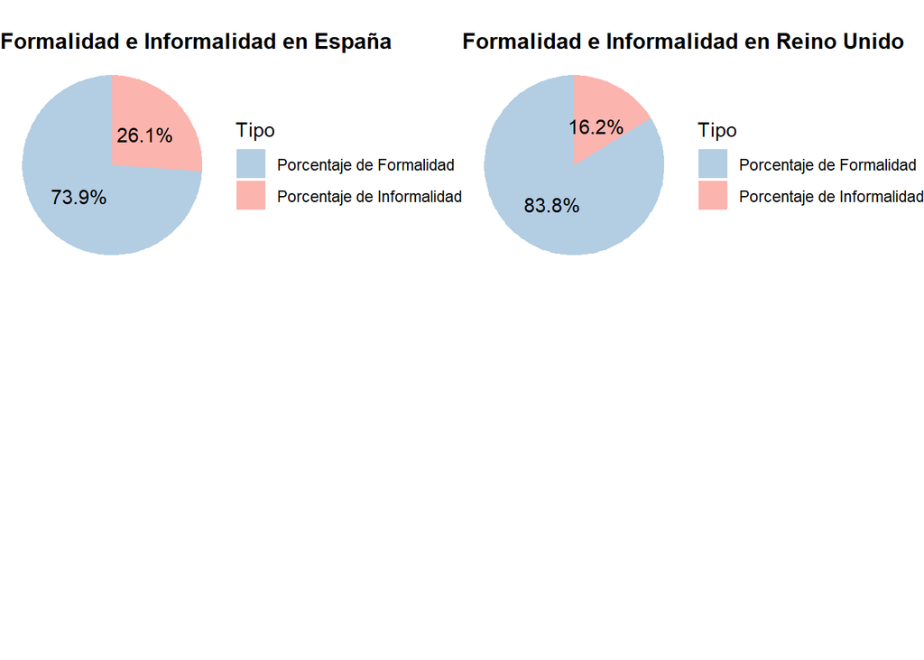

```r
library(ggplot2)
library(gridExtra)
# Convertir porcentajes a números sin el símbolo de porcentaje y preparar los datos
data <- Cuadro_Formalidad_Union %>%
  select(País, 'Porcentaje de Formalidad', 'Porcentaje de Informalidad') %>%
  pivot_longer(cols = c('Porcentaje de Formalidad', 'Porcentaje de Informalidad'),
               names_to = "Tipo",
               values_to = "Porcentaje") %>%
  mutate(Porcentaje = as.numeric(gsub("%", "", Porcentaje)))

# Función para crear gráficos de torta con porcentajes dentro de los segmentos
create_pie_chart <- function(df, country) {
  ggplot(df %>% filter(País == country), aes(x = "", y = Porcentaje, fill = Tipo)) +
    geom_bar(stat = "identity", width = 1) +
    coord_polar("y", start = 0) +
    theme_void() +
    ggtitle(paste("Formalidad e Informalidad en", country)) +
    scale_fill_manual(values = c("Porcentaje de Formalidad" = "#B3CDE3", "Porcentaje de Informalidad" = "#FBB4AE")) +
    geom_text(aes(label = paste0(Porcentaje, "%")), position = position_stack(vjust = 0.5)) +  # Mostrar porcentajes dentro de los segmentos
    theme(legend.position = "right",
          plot.title = element_text(size = 12, face = "bold"))  # Ajustar el tamaño del título
}

# Crear los gráficos con porcentajes dentro de los segmentos
pie_chart_espana <- create_pie_chart(data, "España")
pie_chart_reino_unido <- create_pie_chart(data, "Reino Unido")

# Mostrar los gráficos lado a lado
grid.arrange(pie_chart_espana, pie_chart_reino_unido, ncol = 2, widths = c(1.5, 1.5), heights = c(1, 1.2))
```

En base a la construcción del indicador de formalidad e informalidad laboral en estas bases de datos, podemos observar que España tiene un nivel notablemente más elevado de Informalidad Laboral en relación al Reino Unido; cerca de 10 puntos porcentuales más. Por otro lado, en términos absolutos ambos países tienen cantidades similares de trabajadores informales, mientras que Reino Unido prácticamente duplica a España en trabajores formales y cantidad de trabajadores ocupados. Aunque en principio nos interesan más los porcentajes, dado que permiten comparar mejor las formas de trabajo formal e informal entre ambos países.

Veamos ahora que sucede con la precarización laboral.

### Precarización Laboral en España y Reino Unido

```r
## Calculamos la precarización laboral en España

Cuadro_Precarizacion_ESPAÑA <- bbdd_espana %>%
  summarise( Empleados              = sum((STAPRO %in% c(3,4))*(COEFF*1000),na.rm=TRUE),
             Temporales             = sum((TEMP == 2 )*(COEFF*1000),na.rm=TRUE),
             Sin_pago_horas_extra   = sum((HWOVERPU >= 1 & HWOVERPU <= 98) * (COEFF * 1000), na.rm = TRUE),
             No_perciben_salario_completo  = sum((SIGNISAL %in% c(1,2,3))*(COEFF*1000),na.rm=TRUE),
             Temporales_o_SinPagoHSEXTRA_sin_salario_completo = sum(((TEMP == 2 )| (HWOVERPU >= 1 & HWOVERPU <= 98) | (SIGNISAL %in% c(1,2,3)))*(COEFF*1000),na.rm=TRUE),
             Precarizados=Temporales_o_SinPagoHSEXTRA_sin_salario_completo,
             No_Precarizados=Empleados-Precarizados,
             'Porcentaje de Precarizados'      = percent(Precarizados/Empleados, accuracy = 0.1),
             'Porcentaje de No Precarizados'   = percent(No_Precarizados/Empleados, accuracy = 0.1),
             País="España"
            )

## Calculamos la precarización laboral en Reino Unido

Cuadro_Precarizacion_Reino_Unido <- bbdd_uk %>%
  summarise( Empleados              = sum((STAPRO %in% c(3,4))*(COEFF*1000),na.rm=TRUE),
             Temporales             = sum((TEMP == 2 )*(COEFF*1000),na.rm=TRUE),
             Sin_pago_horas_extra   = sum((HWOVERPU >= 1 & HWOVERPU <= 98) * (COEFF * 1000), na.rm = TRUE),
             No_perciben_salario_completo  = sum((SIGNISAL %in% c(1,2,3))*(COEFF*1000),na.rm=TRUE),
             Temporales_o_SinPagoHSEXTRA_sin_salario_completo = sum(((TEMP == 2 )| (HWOVERPU >= 1 & HWOVERPU <= 98) | (SIGNISAL %in% c(1,2,3)))*(COEFF*1000),na.rm=TRUE),
             Precarizados=Temporales_o_SinPagoHSEXTRA_sin_salario_completo,
             No_Precarizados=Empleados-Precarizados,
             'Porcentaje de Precarizados'      = percent(Precarizados/Empleados, accuracy = 0.1),
             'Porcentaje de No Precarizados'   = percent(No_Precarizados/Empleados, accuracy = 0.1),
             País="Reino Unido"
            )
```

```r
# Agregamos separadores de miles
Cuadro_Precarizacion_ESPAÑA <- Cuadro_Precarizacion_ESPAÑA %>%
  select(País,Empleados,No_Precarizados,Precarizados,'Porcentaje de No Precarizados','Porcentaje de Precarizados') %>%
  mutate(across(c(Empleados,Precarizados,No_Precarizados), ~ format(., big.mark = ".", decimal.mark = ",")))

Cuadro_Precarizacion_Reino_Unido <- Cuadro_Precarizacion_Reino_Unido %>%
  select(País,Empleados,No_Precarizados,Precarizados,'Porcentaje de No Precarizados','Porcentaje de Precarizados') %>%
  mutate(across(c(Empleados,Precarizados,No_Precarizados), ~ format(., big.mark = ".", decimal.mark = ",")))

# Unificar los datasets
Cuadro_Precarizacion_Union <- bind_rows(Cuadro_Precarizacion_ESPAÑA, Cuadro_Precarizacion_Reino_Unido)

#Visualizamos los indicadores de Precarización Laboral en España y Reino Unido
kable(Cuadro_Precarizacion_Union, format = "html", table.attr = "class='table table-striped'", caption = "Indicadores de Precarización del Mercado de Trabajo de España y Reino Unido - 2018. Fuente: EU LFS 2018-Q1") %>%
  kable_styling(full_width = F, position = "center")
```

Indicadores de Precarización del Mercado de Trabajo de España y Reino Unido - 2018. Fuente: EU LFS 2018-Q1

| País | Empleados | No_Precarizados | Precarizados | Porcentaje de No Precarizados | Porcentaje de Precarizados |
| --- | --- | --- | --- | --- | --- |
| España | 16.288.731 | 10.914.366 | 5.374.366 | 67.0% | 33.0% |
| Reino Unido | 27.530.472 | 21.568.683 | 5.961.788 | 78.3% | 21.7% |

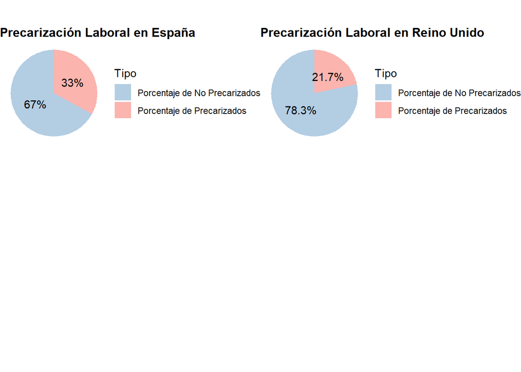

```r
# Convertir porcentajes a números sin el símbolo de porcentaje y preparar los datos
data <- Cuadro_Precarizacion_Union %>%
  select(País, 'Porcentaje de No Precarizados', 'Porcentaje de Precarizados') %>%
  pivot_longer(cols = c('Porcentaje de No Precarizados', 'Porcentaje de Precarizados'),
               names_to = "Tipo",
               values_to = "Porcentaje") %>%
  mutate(Porcentaje = as.numeric(gsub("%", "", Porcentaje)))

# Función para crear gráficos de torta con porcentajes dentro de los segmentos
create_pie_chart <- function(df, country) {
  ggplot(df %>% filter(País == country), aes(x = "", y = Porcentaje, fill = Tipo)) +
    geom_bar(stat = "identity", width = 1) +
    coord_polar("y", start = 0) +
    theme_void() +
    ggtitle(paste("Precarización Laboral en", country)) +
    scale_fill_manual(values = c("Porcentaje de No Precarizados" = "#B3CDE3", "Porcentaje de Precarizados" = "#FBB4AE")) +
    geom_text(aes(label = paste0(Porcentaje, "%")), position = position_stack(vjust = 0.5)) +  # Mostrar porcentajes dentro de los segmentos
    theme(legend.position = "right",
          plot.title = element_text(size = 12, face = "bold"))  # Ajustar el tamaño del título
}

# Crear los gráficos con porcentajes dentro de los segmentos
pie_chart_espana <- create_pie_chart(data, "España")
pie_chart_reino_unido <- create_pie_chart(data, "Reino Unido")

# Mostrar los gráficos lado a lado
grid.arrange(pie_chart_espana, pie_chart_reino_unido, ncol = 2, widths = c(1.5, 1.5), heights = c(1, 1.2))
```

Analizando la precarización laboral en ambos países, nuevamente es posible observar que las condiciones de los trabajadores en España son peores que en Reino Unido, esto es tanto midiendo formalidad como precariedad. En este sentido la precarización laboral es casi 50% mayor en España por sobre el Reino Unido, siendo 1 de cada 3 trabajadores asalariados españoles afectados por esta condición. A su vez, en términos absolutos, volvemos a observar que Reino Unido casi duplica a España en cantidad de empleados y empleados no precarizados, pero no así en empleados precarizados donde los valores absolutos son muy similares, dando cuenta de lo que ya nos explican los porcentajes: esto es, la precarización afecta fuertemente a los trabajadores de España, al compararlos con Reino Unido. Por otro lado, es notable que en Brasil el porcentaje de precarizados es bastante similar al de Reino Unido, aunque este es algo menor. A su vez, en comparación con España, Brasil tiene un porcentaje significativamente mejor de precarizados. Como ya sabemos, tenemos que tener en cuenta que los criterios utilizados para medir precarización en los dos países europeos difiere mucho del utilizado en el capítulo de Brasil.

## 6) Analizar la incidencia de la informalidad y la precariedad según sexo y edad.

En primer lugar construimos las pirámides poblacionales de ambos países para tener una idea inicial de sus estructuras poblacionales por edad y género.

```r
## Cálculo de datos para Pirámide Poblacional de España

# Transformar los valores de SEX a "Hombre" y "Mujer"
bbdd_espana2 <- bbdd_espana %>%
  mutate(Sexo = ifelse(SEX == 1, "Hombre", "Mujer"))

# Crear intervalos de edad en la base de datos
bbdd_espana2 <- bbdd_espana2 %>%
  mutate(Edad_Grupo = cut(AGE, breaks = seq(0, 100, by = 10), right = FALSE, labels = c("0-9", "10-19", "20-29", "30-39", "40-49", "50-59", "60-69", "70-79", "80-89", "90+")))

# Asegurar que Edad_Grupo es un factor
bbdd_espana2$Edad_Grupo <- as.factor(bbdd_espana2$Edad_Grupo)

# Agrupar los datos por intervalos de edad y sexo considerando el factor de expansión
edad_sexo <- bbdd_espana2 %>%
  group_by(Edad_Grupo, Sexo) %>%
  summarise(Count = sum(COEFF * 1000, na.rm = TRUE)) %>%
  ungroup()
```

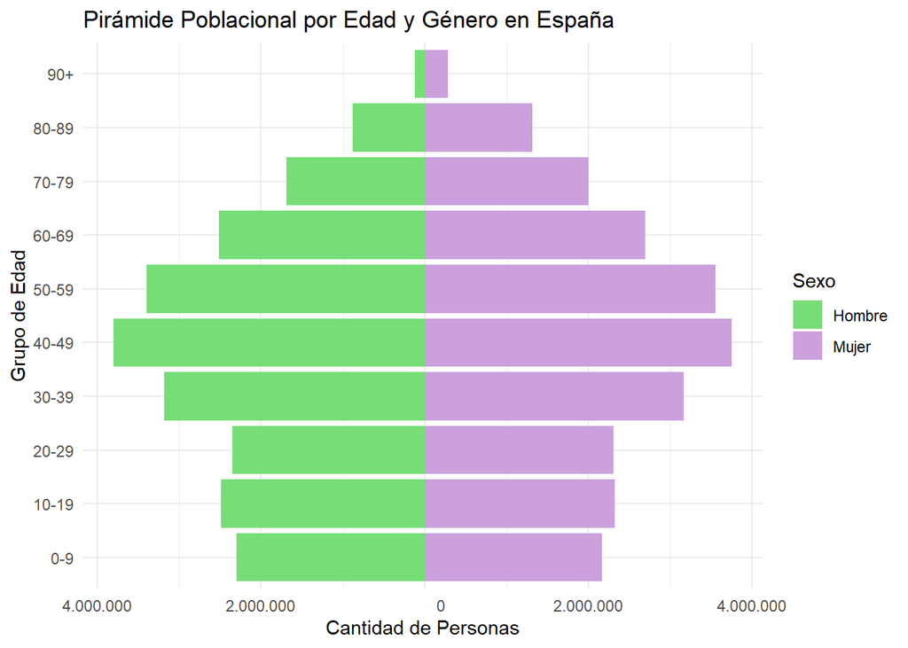

```r
# Crear gráfico de pirámide poblacional de España
ggplot(data = edad_sexo, aes(x = Edad_Grupo, y = ifelse(Sexo == "Hombre", -Count, Count), fill = Sexo)) +
  geom_bar(stat = "identity") +
  coord_flip() +
  scale_y_continuous(labels = function(x) format(abs(x), big.mark = ".", decimal.mark = ".", scientific = FALSE)) +
  labs(y = "Cantidad de Personas", x = "Grupo de Edad", title = "Pirámide Poblacional por Edad y Género en España") +
  theme_minimal() +
  scale_fill_manual(values = c("Hombre" = "#77dd77", "Mujer" = "#cba0dc"))
```

```r
## Cálculo de datos para Pirámide Poblacional de Reino Unido

# Transformar los valores de SEX a "Hombre" y "Mujer"
bbdd_uk2 <- bbdd_uk %>%
  mutate(Sexo = ifelse(SEX == 1, "Hombre", "Mujer"))

# Crear intervalos de edad en la base de datos
bbdd_uk2 <- bbdd_uk2 %>%
  mutate(Edad_Grupo = cut(AGE, breaks = seq(0, 100, by = 10), right = FALSE, labels = c("0-9", "10-19", "20-29", "30-39", "40-49", "50-59", "60-69", "70-79", "80-89", "90+")))

# Asegurar que Edad_Grupo es un factor
bbdd_uk2$Edad_Grupo <- as.factor(bbdd_uk2$Edad_Grupo)

# Agrupar los datos por intervalos de edad y sexo considerando el factor de expansión
edad_sexo_uk <- bbdd_uk2 %>%
  group_by(Edad_Grupo, Sexo) %>%
  summarise(Count = sum(COEFF * 1000, na.rm = TRUE)) %>%
  ungroup()
```

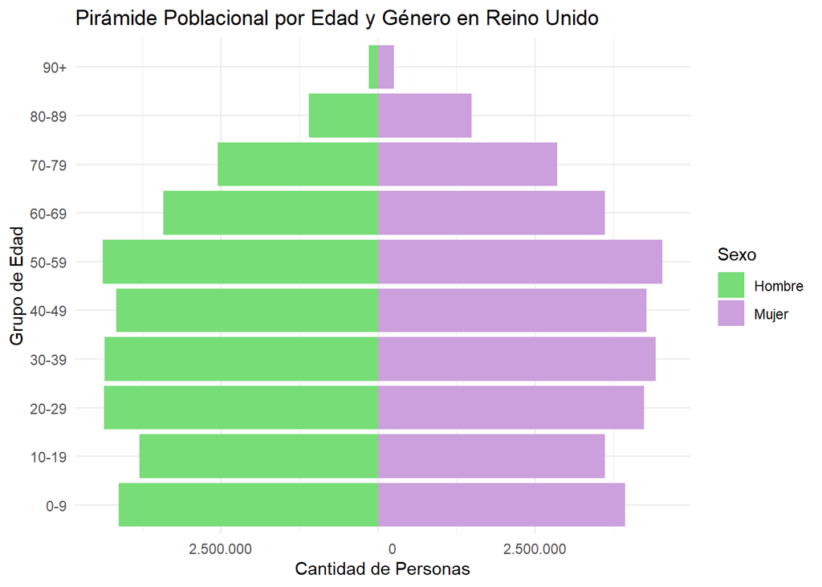

```r
# Crear gráfico de pirámide poblacional de Reino Unido
ggplot(data = edad_sexo_uk, aes(x = Edad_Grupo, y = ifelse(Sexo == "Hombre", -Count, Count), fill = Sexo)) +
  geom_bar(stat = "identity") +
  coord_flip() +
  scale_y_continuous(labels = function(x) format(abs(x), big.mark = ".", scientific = FALSE)) +
  labs(y = "Cantidad de Personas", x = "Grupo de Edad", title = "Pirámide Poblacional por Edad y Género en Reino Unido") +
  theme_minimal() +
  scale_fill_manual(values = c("Hombre" = "#77dd77", "Mujer" = "#cba0dc"))
```

Podemos observar que España tiene una parte significativa de su población entre los 30 y los 60 años, es decir en su edad económicamente activa. Aunque también es posible afirmar que tiene una población bastante envejecida al analizar la cantidad de personas mayores a 70 años, no deja de llamar la atención que una parte significativa de su población, las barras más importantes de la pirámide población se encuentran en el medio de la pirámide, lo cual resulta algo sorpresivo para un país europeo. Esto puede deberse a una multiplicidad de factores como la inmigración, que no vienen al caso para este trabajo.

Por otra parte, la pirámide poblacional de Reino Unido nos revela una típica población envejecida, con una forma de cóncava o de bala, donde a su vez una parte muy importante de su población se encuentra cerca o ya en estado inactivo por su edad.

Ahora bien, pasemos a analizar la incidencia de la informalidad y la precariedad laboral en estas poblaciones.

```r
## Transformamos las variables Sexo y Edad

bbdd_espana3 <- mutate(bbdd_espana,
                      Edad_Periodo = cut(AGE,
                                         breaks = c(15, 30, 45, 60, Inf),
                                         labels = c("15-30", "30-45", "45-60", "60 o más"),
                                         include.lowest = TRUE))%>%
  filter(!is.na(Edad_Periodo))

bbdd_espana3 <- bbdd_espana3 %>%
  mutate(Sexo = case_when(
    SEX == 1 ~ "Hombre",
    SEX == 2 ~ "Mujer",
    TRUE ~ as.character(SEX)
  ))

## Calculamos la informalidad por Sexo y Edad
Cuadro_Formalidad_ESPAÑA2 <- bbdd_espana3 %>%
  group_by(Edad_Periodo, Sexo) %>%  # Agrupar por edad y sexo
 summarise(
    Ocupados = sum((WSTATOR %in% c(1,2)) * (COEFF * 1000), na.rm = TRUE),
    Calificacion_Baja = sum((WSTATOR %in% c(1,2)) * (nuevo_ISCO3D %in% c(4,5,6,7,8,9,999)) * (COEFF * 1000), na.rm = TRUE),
    Empresas_Pequeñas_O_Sin_Empleados = sum((WSTATOR %in% c(1,2)) * (SIZEFIRM %in% c(10,99)) * (COEFF * 1000), na.rm = TRUE),
    Calificacion_Baja_Y_Empre_Peq = sum((WSTATOR %in% c(1,2)) * ((nuevo_ISCO3D %in% c(4,5,6,7,8,9,999)) & (SIZEFIRM %in% c(10,99))) * (COEFF * 1000), na.rm = TRUE),
    Informales = Calificacion_Baja_Y_Empre_Peq,
    Formales = Ocupados - Informales,
    'Porcentaje de Informalidad' = percent(Informales / Ocupados, accuracy = 0.1),
    'Porcentaje de Formalidad' = percent(Formales / Ocupados, accuracy = 0.1),
    País = "España"
  )
# Formatear y redondear las columnas
Cuadro_Formalidad_ESPAÑA2 <- Cuadro_Formalidad_ESPAÑA2 %>%
  select(País, Edad_Periodo, Sexo, Ocupados, Formales, Informales, 'Porcentaje de Formalidad', 'Porcentaje de Informalidad') %>%
  mutate(
    across(c(Ocupados, Formales, Informales), ~ round(., digits = 0)),  # Redondear a enteros
    across(c(Ocupados, Formales, Informales), ~ format(., big.mark = ".", decimal.mark = ","))
  )

# Visualizar los indicadores en formato HTML
kable(Cuadro_Formalidad_ESPAÑA2, format = "html", table.attr = "class='table table-striped'", caption = "Indicadores de Formalidad e Informalidad del Mercado de Trabajo de España según Sexo y Edad - 2018. Fuente: EU LFS 2018-Q1") %>%
  kable_styling(full_width = F, position = "center")
```

Indicadores de Formalidad e Informalidad del Mercado de Trabajo de España según Sexo y Edad - 2018. Fuente: EU LFS 2018-Q1

| País | Edad_Periodo | Sexo | Ocupados | Formales | Informales | Porcentaje de Formalidad | Porcentaje de Informalidad |
| --- | --- | --- | --- | --- | --- | --- | --- |
| España | 15-30 | Hombre | 1.373.808 | 1.065.090 | 308.719 | 77.5% | 22.5% |
| España | 15-30 | Mujer | 1.238.688 | 918.980 | 319.709 | 74.2% | 25.8% |
| España | 30-45 | Hombre | 4.328.531 | 3.348.763 | 979.768 | 77.4% | 22.6% |
| España | 30-45 | Mujer | 3.682.731 | 2.732.066 | 950.665 | 74.2% | 25.8% |
| España | 45-60 | Hombre | 4.079.566 | 2.968.407 | 1.111.159 | 72.8% | 27.2% |
| España | 45-60 | Mujer | 3.321.597 | 2.365.178 | 956.419 | 71.2% | 28.8% |
| España | 60 o más | Hombre | 750.057 | 521.411 | 228.645 | 69.5% | 30.5% |
| España | 60 o más | Mujer | 552.722 | 354.946 | 197.777 | 64.2% | 35.8% |

Del cuadro anterior es posible extraer que en España el porcentaje de Informalidad tiene a ser mayor para las mujeres que para los hombres. A su vez, la variable de la edad tiende a mantenerse bastante estable a lo largo de los distintos grupos etarios, con la salvedad del último grupo (60 años o más), donde la informalidad tiende a ser más preponderante y la brecha entre hombres y mujeres, a su vez, se vuelve más importante. Veamos qué sucede con el Reino Unido.

```r
## Transformamos las variables Sexo y Edad

bbdd_uk3 <- mutate(bbdd_uk,
                      Edad_Periodo = cut(AGE,
                                         breaks = c(15, 30, 45, 60, Inf),
                                         labels = c("15-30", "30-45", "45-60", "60 o más"),
                                         include.lowest = TRUE))%>%
  filter(!is.na(Edad_Periodo))

bbdd_uk3 <- bbdd_uk3 %>%
  mutate(Sexo = case_when(
    SEX == 1 ~ "Hombre",
    SEX == 2 ~ "Mujer",
    TRUE ~ as.character(SEX)
  ))

## Calculamos la informalidad por Sexo y Edad
Cuadro_Formalidad_UK2 <- bbdd_uk3 %>%
  group_by(Edad_Periodo, Sexo) %>%  # Agrupar por edad y sexo
  summarise(
    Ocupados = sum((WSTATOR %in% c(1,2)) * (COEFF * 1000), na.rm = TRUE),
    Calificacion_Baja = sum((WSTATOR %in% c(1,2)) * (nuevo_ISCO3D %in% c(4,5,6,7,8,9,999)) * (COEFF * 1000), na.rm = TRUE),
    Empresas_Pequeñas_O_Sin_Empleados = sum((WSTATOR %in% c(1,2)) * (SIZEFIRM %in% c(10,99)) * (COEFF * 1000), na.rm = TRUE),
    Calificacion_Baja_Y_Empre_Peq = sum((WSTATOR %in% c(1,2)) * ((nuevo_ISCO3D %in% c(4,5,6,7,8,9,999)) & (SIZEFIRM %in% c(10,99))) * (COEFF * 1000), na.rm = TRUE),
    Informales = Calificacion_Baja_Y_Empre_Peq,
    Formales = Ocupados - Informales,
    'Porcentaje de Informalidad' = percent(Informales / Ocupados, accuracy = 0.1),
    'Porcentaje de Formalidad' = percent(Formales / Ocupados, accuracy = 0.1),
    País = "Reino Unido"
  )
# Formatear y redondear las columnas
Cuadro_Formalidad_UK2 <- Cuadro_Formalidad_UK2 %>%
  select(País, Edad_Periodo, Sexo, Ocupados, Formales, Informales, 'Porcentaje de Formalidad', 'Porcentaje de Informalidad') %>%
  mutate(
    across(c(Ocupados, Formales, Informales), ~ round(., digits = 0)),  # Redondear a enteros
    across(c(Ocupados, Formales, Informales), ~ format(., big.mark = ".", decimal.mark = ","))
  )

# Visualizar los indicadores en formato HTML
kable(Cuadro_Formalidad_UK2, format = "html", table.attr = "class='table table-striped'", caption = "Indicadores de Formalidad e Informalidad del Mercado de Trabajo de Reino Unido según Sexo y Edad - 2018. Fuente: EU LFS 2018-Q1") %>%
  kable_styling(full_width = F, position = "center")
```

Indicadores de Formalidad e Informalidad del Mercado de Trabajo de Reino Unido según Sexo y Edad - 2018. Fuente: EU LFS 2018-Q1

| País | Edad_Periodo | Sexo | Ocupados | Formales | Informales | Porcentaje de Formalidad | Porcentaje de Informalidad |
| --- | --- | --- | --- | --- | --- | --- | --- |
| Reino Unido | 15-30 | Hombre | 3.956.489 | 3.271.949 | 684.539 | 82.7% | 17.3% |
| Reino Unido | 15-30 | Mujer | 3.563.962 | 3.072.087 | 491.875 | 86.2% | 13.8% |
| Reino Unido | 30-45 | Hombre | 5.802.848 | 4.868.907 | 933.941 | 83.9% | 16.1% |
| Reino Unido | 30-45 | Mujer | 5.032.640 | 4.396.030 | 636.610 | 87.4% | 12.6% |
| Reino Unido | 45-60 | Hombre | 5.587.477 | 4.568.458 | 1.019.019 | 81.8% | 18.2% |
| Reino Unido | 45-60 | Mujer | 5.262.195 | 4.508.382 | 753.813 | 85.7% | 14.3% |
| Reino Unido | 60 o más | Hombre | 1.848.435 | 1.403.383 | 445.052 | 75.9% | 24.1% |
| Reino Unido | 60 o más | Mujer | 1.388.985 | 1.088.502 | 300.482 | 78.4% | 21.6% |

Lo primero que notamos al analizar esta tabla es que, a diferencia de lo que observamos en España, en Reino Unido la informalidad laboral afecta de manera más notoria a los hombres por sobre las mujeres en todos los grupos etarios. Por otro lado, el factor etario presenta comportamientos similares a lo analizado en el caso español. Esto es, en los primeros tres grupos etarios las diferencias en los niveles de informalidad no son demasiado notorios, mientras que en el grupo etario de 60 años o más, se observa un salto importante, aumentando cerca de un 30% respecto de los otros grupos etarios y sobrepasando el umbral del 20% para ambos sexos.

Por otra parte, comparando contra Brasil, vemos que la informalidad parece afectar de manera diferencial a los hombres por sobre las mujeres, aunque de una manera menos marcada que como notamos en los países europeos. En ese sentido, parece ser que la informalidad es un fenómeno más extendido en el país latinoamericano, pero la variable sexo no parece afectar tanto como lo hace en España y Reino Unido.

Analicemos por último el fenómeno de la precariedad laboral.

```r
## Calculamos la precariedad laboral por Sexo y Edad para España

Cuadro_Precarizacion_ESPAÑA3 <- bbdd_espana3 %>%
  group_by(Edad_Periodo, Sexo) %>%  # Agrupar por edad y sexo
  summarise(
    Empleados = sum((STAPRO %in% c(3,4)) * (COEFF * 1000), na.rm = TRUE),
    Temporales = sum((TEMP == 2) * (COEFF * 1000), na.rm = TRUE),
    Sin_pago_horas_extra = sum((HWOVERPU >= 1 & HWOVERPU <= 98) * (COEFF * 1000), na.rm = TRUE),
    No_perciben_salario_completo = sum((SIGNISAL %in% c(1,2,3)) * (COEFF * 1000), na.rm = TRUE),
    Temporales_o_SinPagoHSEXTRA_sin_salario_completo = sum(((TEMP == 2) | (HWOVERPU >= 1 & HWOVERPU <= 98) | (SIGNISAL %in% c(1,2,3))) * (COEFF * 1000), na.rm = TRUE),
    Precarizados = Temporales_o_SinPagoHSEXTRA_sin_salario_completo,
    No_Precarizados = Empleados - Precarizados,
    'Porcentaje de Precarizados' = percent(Precarizados / Empleados, accuracy = 0.1),
    'Porcentaje de No Precarizados' = percent(No_Precarizados / Empleados, accuracy = 0.1),
    País = "España"
  ) %>%
  mutate(
    across(where(is.numeric), ~ ifelse(is.na(.), 0, .)),  # Manejo de NA (si aplica)
    across(c(Empleados,Precarizados, No_Precarizados), ~ round(., digits = 0)),  # Redondear a enteros
    across(c(Empleados,Precarizados, No_Precarizados), ~ format(., big.mark = ".", decimal.mark = ","))  # Formatear números
  ) %>%
  select(País, Edad_Periodo, Sexo, Empleados, No_Precarizados, Precarizados, 'Porcentaje de No Precarizados', 'Porcentaje de Precarizados')
# Visualizar los indicadores en formato HTML
kable(Cuadro_Precarizacion_ESPAÑA3, format = "html", table.attr = "class='table table-striped'", caption = "Indicadores de Precarización del Mercado de Trabajo de España según Sexo y Edad - 2018. Fuente: EU LFS 2018-Q1") %>%
  kable_styling(full_width = F, position = "center")
```

Indicadores de Precarización del Mercado de Trabajo de España según Sexo y Edad - 2018. Fuente: EU LFS 2018-Q1

| País | Edad_Periodo | Sexo | Empleados | No_Precarizados | Precarizados | Porcentaje de No Precarizados | Porcentaje de Precarizados |
| --- | --- | --- | --- | --- | --- | --- | --- |
| España | 15-30 | Hombre | 1.259.786 | 531.748 | 728.037 | 42.2% | 57.8% |
| España | 15-30 | Mujer | 1.167.506 | 457.853 | 709.653 | 39.2% | 60.8% |
| España | 30-45 | Hombre | 3.611.833 | 2.469.974 | 1.141.859 | 68.4% | 31.6% |
| España | 30-45 | Mujer | 3.307.415 | 2.198.160 | 1.109.255 | 66.5% | 33.5% |
| España | 45-60 | Hombre | 3.127.444 | 2.372.215 | 755.229 | 75.9% | 24.1% |
| España | 45-60 | Mujer | 2.890.505 | 2.128.824 | 761.681 | 73.6% | 26.4% |
| España | 60 o más | Hombre | 484.221 | 400.774 | 83.448 | 82.8% | 17.2% |
| España | 60 o más | Mujer | 440.020 | 354.816 | 85.204 | 80.6% | 19.4% |

```r
## Calculamos la precariedad laboral por Sexo y Edad para Reino Unido

Cuadro_Precarizacion_UK3 <- bbdd_uk3 %>%
  group_by(Edad_Periodo, Sexo) %>%  # Agrupar por edad y sexo
  summarise(
    Empleados = sum((STAPRO %in% c(3,4)) * (COEFF * 1000), na.rm = TRUE),
    Temporales = sum((TEMP == 2) * (COEFF * 1000), na.rm = TRUE),
    Sin_pago_horas_extra = sum((HWOVERPU >= 1 & HWOVERPU <= 98) * (COEFF * 1000), na.rm = TRUE),
    No_perciben_salario_completo = sum((SIGNISAL %in% c(1,2,3)) * (COEFF * 1000), na.rm = TRUE),
    Temporales_o_SinPagoHSEXTRA_sin_salario_completo = sum(((TEMP == 2) | (HWOVERPU >= 1 & HWOVERPU <= 98) | (SIGNISAL %in% c(1,2,3))) * (COEFF * 1000), na.rm = TRUE),
    Precarizados = Temporales_o_SinPagoHSEXTRA_sin_salario_completo,
    No_Precarizados = Empleados - Precarizados,
    'Porcentaje de Precarizados' = percent(Precarizados / Empleados, accuracy = 0.1),
    'Porcentaje de No Precarizados' = percent(No_Precarizados / Empleados, accuracy = 0.1),
    País = "Reino Unido"
  ) %>%
  mutate(
    across(where(is.numeric), ~ ifelse(is.na(.), 0, .)),  # Manejo de NA (si aplica)
    across(c(Empleados,Precarizados, No_Precarizados), ~ round(., digits = 0)),  # Redondear a enteros
    across(c(Empleados,Precarizados, No_Precarizados), ~ format(., big.mark = ".", decimal.mark = ","))  # Formatear números
  ) %>%
  select(País, Edad_Periodo, Sexo, Empleados, No_Precarizados, Precarizados, 'Porcentaje de No Precarizados', 'Porcentaje de Precarizados')
# Visualizar los indicadores en formato HTML
kable(Cuadro_Precarizacion_UK3, format = "html", table.attr = "class='table table-striped'", caption = "Indicadores de Precarización del Mercado de Trabajo de Reino Unido según Sexo y Edad - 2018. Fuente: EU LFS 2018-Q1") %>%
  kable_styling(full_width = F, position = "center")
```

Indicadores de Precarización del Mercado de Trabajo de Reino Unido según Sexo y Edad - 2018. Fuente: EU LFS 2018-Q1

| País | Edad_Periodo | Sexo | Empleados | No_Precarizados | Precarizados | Porcentaje de No Precarizados | Porcentaje de Precarizados |
| --- | --- | --- | --- | --- | --- | --- | --- |
| Reino Unido | 15-30 | Hombre | 3.587.647 | 2.895.318 | 692.329 | 80.7% | 19.3% |
| Reino Unido | 15-30 | Mujer | 3.419.313 | 2.701.245 | 718.068 | 79.0% | 21.0% |
| Reino Unido | 30-45 | Hombre | 4.773.511 | 3.707.723 | 1.065.788 | 77.7% | 22.3% |
| Reino Unido | 30-45 | Mujer | 4.527.575 | 3.509.641 | 1.017.934 | 77.5% | 22.5% |
| Reino Unido | 45-60 | Hombre | 4.290.413 | 3.358.770 | 931.643 | 78.3% | 21.7% |
| Reino Unido | 45-60 | Mujer | 4.608.433 | 3.510.692 | 1.097.741 | 76.2% | 23.8% |
| Reino Unido | 60 o más | Hombre | 1.211.538 | 983.368 | 228.171 | 81.2% | 18.8% |
| Reino Unido | 60 o más | Mujer | 1.112.042 | 901.927 | 210.114 | 81.1% | 18.9% |

# Bibliografía

ILO (2024). International Standard Classification of Occupations (ISCO). Disponible en línea: https://ilostat.ilo.org/methods/concepts-and-definitions/classification-occupation/

Pok, C. (2013) Informalidad y precariedad laboral: Los desarrollos conceptuales de su abordaje frente a los desafíos de su medición. Congreso Nacional de Estudios del Trabajo. Buenos Aires, 2013.